# Week 1 Intro to Classification Models: knn and Naive Bayes

San Cannon and Xuan Pham

# R Packages

The packages you will need to install for the week are **knitr**, **class**, **e1071**, **fnn**, and **dummies**

# Classification Models

Our task for this week is to create models that predict categorical class labels. In particular, we will look at two classifical models: **naive bayes** and **k-nearest neighbor (knn)**.

These are **supervised** learning algorithms.

Like other classifiers, Naive Bayes classifiers look to sort items into buckets. These classifiers use probabilities to make decisions on how to classify items. The basic idea is: Find out the probability of the previously unseen instance belonging to each class, then simply pick the most probable class.

# Probability refresher

- Prior probability: $P(A)$ - probability of event A occuring
- Joint probability: $P(A \cap B)= P(A,B)$ - the probability of events A **and** B both occuring
- Conditional probability: $P(A \mid B)$ - probability of event A occuring given that event B has occurred. Not necessarily the same as $P(B \mid A)$ which is the probability that B occurs given that A has occured.
- Relationship between prior, joint, and conditional: $P(A,B) = P(B \mid A)P(A) = P(A \mid B)P(B)$
- Independence: A is independent of B if $P(A \mid B) = P(A)$

Use these relationships to get Bayes’ rule:
$$P(A \mid B) = \frac{P(B \mid A) \, P(A)}{P(B)}$$

where * $P(A \mid B)$ = probability of instance B being in class A. This is what we are trying to compute * $P(B \mid A)$ = probability of generating instance B given class A. We can imagine that being in class A causes you to have feature B with some probability * $P(A)$ = probability of occurrence of class A. This is just how frequent the class A is in our data set * $P(B)$ = probability of instance B occurring. This will be the same for all classes so you may not need to use it.

We are making follow up customer calls and we get to a customer called “Drew”. There is no salutation noted and the “Sex” field in the database is blank. How do we address “Drew”?

Well we know that we have two classes $c1$ = male, and $c2$ = female.

Classifying “Drew” as male or female is equivalent to asking if it is more probable that “Drew” is male or female. That is: which is greater $p(male | drew)$ or $p(female | drew)$ Are we calling Drew Carey or Drew Barrymore?

$$P(Male \mid Drew) = \frac{P(Drew \mid Male) \, P(Male)}{P(Drew)}$$

compared to:

$$P(Female \mid Drew) = \frac{P(Drew \mid Female) \, P(Female)}{P(Drew)}$$

Say these are the clean entries in our data:

| **Name** | **Sex** |
| --- | --- |
| Drew | Male |
| Claudia | Female |
| Drew | Female |
| Drew | Female |
| Alberto | Male |
| Karin | Female |
| Nina | Female |
| Sergio | Male |

$p(male | drew) = \frac {1/3 * 3/8}{3/8} = \frac{0.125}{3/8}$

$p(female | drew) = \frac {2/5 * 5/8}{3/8} = \frac{0.250}{3/8}$

It is more likely that our customer is female so we should probably address “Drew” as “Ms.”

What if we have more information? How do we use more attributes to improve the percentages?

What if our data looked like this?

| **Name** | **Over 5ft7in** | **Eyes** | **Hair** | **Sex** |
| --- | --- | --- | --- | --- |
| Drew | No | Blue | Short | Male |
| Claudia | Yes | Brown | Long | Female |
| Drew | No | Blue | Long | Female |
| Drew | No | Blue | Long | Female |
| Alberto | Yes | Brown | Short | Male |
| Karin | No | Blue | Long | Female |
| Nina | Yes | Brown | Short | Female |
| Sergio | Yes | Blue | Long | Male |

What are the conditional probabilities?

| Sex | Over 5f7in | P |
| --- | --- | --- |
| Male | Yes | 2/3 |
| Male | No | 1/3 |
| Female | Yes | 2/5 |
| Female | No | 3/5 |

[output not shown]

| Sex | Hair | P |
| --- | --- | --- |
| Male | Long | 1/3 |
| Male | Short | 2/3 |
| Female | Long | 4/5 |
| Female | Short | 1/5 |

So our calculations are:

$p(male | drew) = {2/3 * 2/3 * 1/3} = .148$

$p(female | drew) = {2/5 *3/5 *4/5 } = .192$

```r
library(e1071)

#create dataframe - note that cust_data has 9 rows but sex only has 8.  The "unknown" Drew is the last row of the DF.

names <- c("Drew","Claudia","Drew","Drew","Alberto","Karin","Nina","Sergio","Drew")
over57 <-c("No","Yes","No","No","Yes","No","Yes","Yes","Yes")
eyes <- c("Blue","Brown","Blue", "Blue","Brown","Blue","Brown","Blue","Blue")
hair <- c("Short","Long","Long","Long","Short","Long","Short","Long","Long")
sex <- c("Male","Female","Male","Male","Male","Female","Female","Female")
names<-as.factor(names)
over57 <-as.factor(over57)
eyes<- as.factor(eyes)
hair<-as.factor(hair)
sex<- as.factor(sex)
cust_data <-data.frame(names,over57,eyes,hair)
cust_data
```

```
##     names over57  eyes  hair
## 1    Drew     No  Blue Short
## 2 Claudia    Yes Brown  Long
## 3    Drew     No  Blue  Long
## 4    Drew     No  Blue  Long
## 5 Alberto    Yes Brown Short
## 6   Karin     No  Blue  Long
## 7    Nina    Yes Brown Short
## 8  Sergio    Yes  Blue  Long
## 9    Drew    Yes  Blue  Long
```

```r
#split data into known Drew's and our unknown Drew
train <- cust_data[1:8,]
test <- cust_data[9,]


#train model
drew_classifier <- naiveBayes(sex ~ ., data = train)
drew_classifier
```

```
##
## Naive Bayes Classifier for Discrete Predictors
##
## Call:
## naiveBayes.default(x = X, y = Y, laplace = laplace)
##
## A-priori probabilities:
## Y
## Female   Male
##    0.5    0.5
##
## Conditional probabilities:
##         names
## Y        Alberto Claudia Drew Karin Nina Sergio
##   Female    0.00    0.25 0.00  0.25 0.25   0.25
##   Male      0.25    0.00 0.75  0.00 0.00   0.00
##
##         over57
## Y          No  Yes
##   Female 0.25 0.75
##   Male   0.75 0.25
##
##         eyes
## Y        Blue Brown
##   Female 0.50  0.50
##   Male   0.75  0.25
##
##         hair
## Y        Long Short
##   Female 0.75  0.25
##   Male   0.50  0.50
```

```r
# Our Drew is the last row - what's the verdict?
predict(drew_classifier, test)
```

```
## [1] Male
## Levels: Female Male
```

# k-Nearest Neighbor (kNN): A Lazy Classification Model

kNN is called a “lazy learner” because it does not perform abstraction. Lantz (2013) noted:

*In a single sentence, nearest neighbor classifiers are defined by their characteristics of classifying unlabeled examples by assigning them the class of the most similar labeled examples* (Lantz 2013, p. 66).

When comparing among neighbors, we need to use a distance function. The most common way to measure distance is **Euclidean distance**, or the shortest direct route.

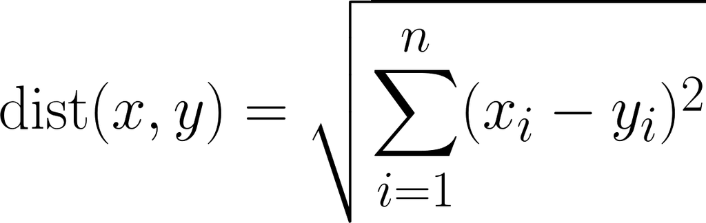

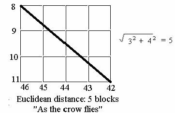

# How many neighbors (k)?

When choosing the number of k, we need to consider the **bias-variance tradeoff**. A large k reduces the variance caused by noisy data but can cause bias in that we risk ignoring small (and important) patterns (Lantz 2013, p. 71).

# kNN requires data transformation into a standard range.

## Min-Max Normalization

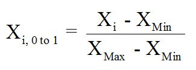

Also see page 73 of Lantz text

# Z score standardization

Min-max isn’t the only kind of standardization:

[figure not shown]

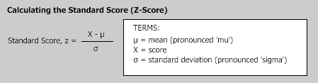

How would the KNN model classify the new Drew? Knn needs numeric data not factors so we need to create dummy variables.

Why is that? Because KNN relies on distances and the dummy variables allow for distance calculation.

```r
head(cust_data)
```

```
##     names over57  eyes  hair
## 1    Drew     No  Blue Short
## 2 Claudia    Yes Brown  Long
## 3    Drew     No  Blue  Long
## 4    Drew     No  Blue  Long
## 5 Alberto    Yes Brown Short
## 6   Karin     No  Blue  Long
```

```r
library(dummies)

# example data
dummy.df <- dummy.data.frame(cust_data, sep = ":")


dummy.df
```

```
##   names:Alberto names:Claudia names:Drew names:Karin names:Nina
## 1             0             0          1           0          0
## 2             0             1          0           0          0
## 3             0             0          1           0          0
## 4             0             0          1           0          0
## 5             1             0          0           0          0
## 6             0             0          0           1          0
## 7             0             0          0           0          1
## 8             0             0          0           0          0
## 9             0             0          1           0          0
##   names:Sergio over57:No over57:Yes eyes:Blue eyes:Brown hair:Long
## 1            0         1          0         1          0         0
## 2            0         0          1         0          1         1
## 3            0         1          0         1          0         1
## 4            0         1          0         1          0         1
## 5            0         0          1         0          1         0
## 6            0         1          0         1          0         1
## 7            0         0          1         0          1         0
## 8            1         0          1         1          0         1
## 9            0         0          1         1          0         1
##   hair:Short
## 1          1
## 2          0
## 3          0
## 4          0
## 5          1
## 6          0
## 7          1
## 8          0
## 9          0
```

```r
train <- dummy.df[1:8,]
test <- dummy.df[9,]
```

We will use the **class** package to perform kNN.

```r
library(class)

# What about our new Drew?

set.seed(123)
pred_knn<-knn(train=train, test=test,cl=sex, k=2)
pred_knn
```

```
## [1] Male
## Levels: Female Male
```

In reality, we will be dealing with much larger data sets and we will want to predict outcomes for more than one case. Let’s see what happens with some “real” data.